# Signals and Systems, but in PYTHON :)

Continous signal: is continous over the given time domain and the amplitude of the signal is known for all time in the domain.

#### Lets us first import the required libraries

```python
import numpy as np
import matplotlib.pyplot as plt
plt.style.use(['science','no-latex','grid'])
```

## Unit impulse function : δ(t)

An unit impulse function δ(t) is defined as having an amplitude of 1 at t=0s and 0 amplitude for every value other than t=0s.

How the signals arrives?

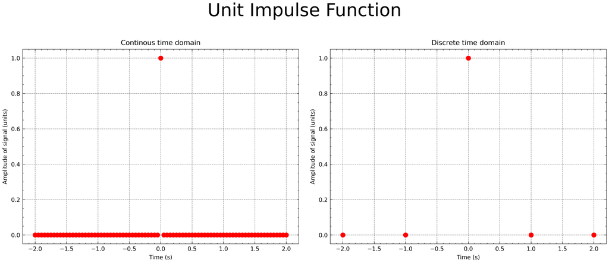

```python
fig, axes = plt.subplots(1, 2, figsize=(12,5))
axs=axes[0]
t = np.linspace(-2,2,81)
amp = np.zeros(81)
amp[40]=1
axs.set_title("Continous time domain")
axs.set_xlabel("Time (s)")
axs.set_ylabel("Amplitude of signal (units)")
axs.scatter(t,amp,color='r')

axs=axes[1]
t = np.linspace(-2,2,5)
amp= np.zeros(5)
amp[2]=1
axs.set_title("Discrete time domain")
axs.set_xlabel("Time (s)")
axs.set_ylabel("Amplitude of signal (units)")
axs.scatter(t,amp,color='r')

fig.suptitle('Unit Impulse Function', y=1.03, fontsize=25)
fig.tight_layout(h_pad=2, w_pad=2)
fig.savefig('images/unit_impulse_func.png',dpi=200,bbox_inches='tight')
plt.show()
```

Now these are the continous time domain and discrete time domain unit impulse function. As you can see the value of the signal at t=0s is 1units in amplitude.

## Step signal or step function :

A step signal or step function is defined as having an amplitude 'A' units for t>=0s and 0 for t<0s.

**An Unit step signal is the same as step signal or step function but the amplitude is 1 unit.**

```python
def sctd(ampset):
    return np.concatenate([np.zeros(50),np.ones(50)])
def sdtd(ampset):
    return np.array([0,0,ampset,ampset,ampset])
```

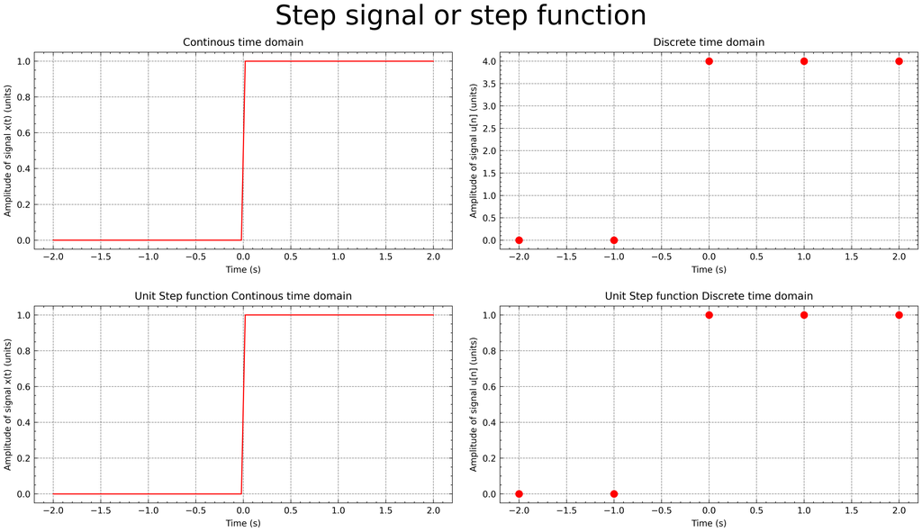

```python
fig, axes = plt.subplots(2, 2, figsize=(12,7))
axs=axes[0][0]
amp=[]
t = np.linspace(-2,2,100)
amp = sctd(4)
axs.set_xlabel("Time (s)")
axs.set_ylabel("Amplitude of signal x(t) (units)")
axs.set_title("Continous time domain")
axs.plot(t,amp,color='r')

axs=axes[0][1]
amp=[]
t = np.linspace(-2,2,5)
amp = sdtd(4)
axs.set_xlabel("Time (s)")
axs.set_ylabel("Amplitude of signal u[n] (units)")
axs.set_title("Discrete time domain")
axs.scatter(t,amp,color='r')

axs=axes[1][0]
amp=[]
t = np.linspace(-2,2,100)
amp = sctd(1)
axs.set_xlabel("Time (s)")
axs.set_ylabel("Amplitude of signal x(t) (units)")
axs.set_title("Unit Step function Continous time domain")
axs.plot(t,amp,color='r')

axs = axes[1][1]
amp=[]
t = np.linspace(-2,2,5)
amp = sdtd(1)
axs.set_xlabel("Time (s)")
axs.set_ylabel("Amplitude of signal u[n] (units)")
axs.set_title("Unit Step function Discrete time domain")
axs.scatter(t,amp,color='r')

fig.suptitle('Step signal or step function', fontsize=25)
fig.tight_layout(h_pad=2, w_pad=2)
fig.savefig('images/step_func.png',dpi=200,bbox_inches='tight')
plt.show()
```

## Ramp signal :

A Ramp signal is defined as having an amplitude 'At' units for t>=0s and 0 for t<0s where a is a constant and t is the time.

x(t) = At for t>=0s and 0 units for t<0s.

For this example, we will consider A = 3 units. (or slope of the curve as 3 units)

**If A=1 unit, we will get unit ramp signal, whose slope of signal will be 1unit.**

```python
def rctd():
    return np.concatenate([np.zeros(50),np.ones(50)])

def rdtd():
    return np.array([0,0,1,1,1])
```

```python
fig, axes = plt.subplots(2, 2, figsize=(12,7))
a=3

axs = axes[0][0]
t = np.linspace(-2,2,100)
amp = a*rctd()*t
axs.set_xlabel("Time (s)")
axs.set_ylabel("Amplitude of signal x(t) (units)")
axs.set_title("Continous time domain")
axs.plot(t,amp,color='r')

axs = axes[0][1]
t = np.linspace(-2,2,5)
amp = a*rdtd()*t
axs.set_xlabel("Time (s)")
axs.set_ylabel("Amplitude of signal x(t) (units)")
axs.set_title("Discrete time domain")
axs.scatter(t,amp,color='r')


axs = axes[1][0]
t = np.linspace(-2,2,100)
amp = rctd()*t
axs.set_xlabel("Time (s)")
axs.set_ylabel("Amplitude of signal x(t) (units)")
axs.set_title("Continous time domain")
axs.plot(t,amp,color='r')

axs = axes[1][1]
t = np.linspace(-2,2,5)
amp = rdtd()*t
axs.set_xlabel("Time (s)")
axs.set_ylabel("Amplitude of signal x(t) (units)")
axs.set_title("Discrete time domain")
axs.scatter(t,amp,color='r')


fig.suptitle('Ramp signal', y=1.03, fontsize=25)
fig.tight_layout(h_pad=2, w_pad=2)
fig.savefig('images/ramp_func.png',dpi=200,bbox_inches='tight')
plt.show()
```

[figure not shown]